# Informe práctico 2

VISCAINO, Lucas Esteban

```r
knitr::opts_chunk$set(
    echo = TRUE,
    fig.height = 8,
    fig.width = 12
)
knitr::opts_chunk$set(fig.width=12, fig.height=8)


library(tidyverse)
library(gt)
library(patchwork)
library(viridis)
library(rnaturalearth)
theme_lucas <-
  list(
    theme_minimal(),
    theme(
      axis.title.x=element_text(hjust = 0.5 , vjust = 0.5),
      axis.title.y = element_text(hjust = 0.5 , vjust = 0.5),
      plot.title=element_text(face="bold",hjust = 0.5 , vjust = 0.5),
      legend.position = "right",
      legend.key.size = unit(0.85,"char"),
      plot.caption = element_text(size = rel(0.7), hjust = 1, vjust = 1)
    )
  )


url <- "https://drive.usercontent.google.com/download?id=1ngkZjucrq7DWQ3uTRtUIaXC6z1ahWbfZ&export=download&authuser=0&confirm=t&uuid=25b215cb-e0a1-4504-b6a4-826538cbe5d4&at=APZUnTWtkwwxIPzIEFdlhqNn7XRv%3A1716627659697"
archivo <- "datos/vuelos.csv"

if (!file.exists(archivo)) {
  dir.create("datos", showWarnings = FALSE)
  download.file(url, archivo)
}

vuelos <- readr::read_csv(archivo)|>mutate (mes = month(fecha_hora_utc, label=TRUE,abbr=TRUE,locale="Spanish_Argentina.utf8"))
```

# 1 Segundo parcial práctico

Usaremos una base de datos de **Aterrizajes y despegues procesados por la Administración Nacional de Aviación Civil (ANAC).**

## 1.1 Parte 1

**Pregunta:** ¿Cómo varia el promedio de pasajeros por vuelo para cada aerolínea (tanto para vuelos domésticos como internacionales)? ¿Cómo se comporta ese promedio a lo largo del año?

### 1.1.1 Introducción

El informe analizará una versión limpia de los datos de de la base de datos de **Aterrizajes y despuegues procesados por la Administración Nacional de Aviación Civil (ANAC)**, provista por la cátedra. La base de datos cuenta con datos clave para identificar vuelos, tales como la hora de la operación (expresada en UTC), tipo de opreación (Despegue o Aterrizaje), ruta, entre otras. También resulta relevante destacar la columna de calidad_dato, que nos informa si el dato es parcial o final, para poder tener en cuenta dentro del análisis que deseemos hacer.

### 1.1.2 Enfoque

Para abordar la resolución, se realizó un análisis previo de los datos, obteniendo como resultado las 5 aerolíneas a utilizar tanto para vuelos domésticos como internacionales, respectivamente.  
Se tomaron en cuenta únicamente los vuelos que cuentan con datos definitivos, para asegurar la calidad de la información obtenida, así cómo también los vuelos clasificados como regulares, descartando vuelos especiales como vuelos privados o vuelos escuela, entre otros. Adicionalmente, para vuelos domésticos, se filtraron los datos por vuelos categorizados como Aterrizaje. Finalmente, se contabilizaron los totales de operaciones realizadas y se seleccionaron las 5 aerolíneas con más vuelos para cada división (domésticos e internacionales).  
La lista de aerolíneas seleccionadas se puede ver en la sección de Análisis.

```r
vuel_domestico <- head(arrange(vuelos |>
                                 group_by(aerolinea,clasificacion_vuelo,clase_vuelo,tipo_movimiento,calidad_dato) |>
                                 summarise(tot_vuelos = n())|>
                                 filter(clasificacion_vuelo=="Doméstico" & clase_vuelo=="regular" & tipo_movimiento == "Aterrizaje" & calidad_dato=="DEFINITIVO"),
                               desc(tot_vuelos)),5) ##manip de datos para obtener las 5 aerolineas con mas vuelos que cumplan los criterios
##por algun motivo no me toma la "Doméstico" dentro de filter por lo que use !="Internacional"

aero_domest <- c(vuel_domestico$aerolinea) ##string para filtrar facilmente aerolineas


vuel_inter <- head(arrange(vuelos |>
                             group_by(aerolinea,clasificacion_vuelo,clase_vuelo,calidad_dato) |>
                             summarise(tot_vuelos = n())|>
                             filter(clasificacion_vuelo=="Internacional" & clase_vuelo=="regular"& calidad_dato=="DEFINITIVO"),
                           desc(tot_vuelos)),5) ##manip de datos para obtener las 5 aerolineas con mas vuelos que cumplan los criterios

aero_inter <- c(vuel_inter$aerolinea) ##string para filtrar facilmente aerolineas

data_domesticos <- vuelos |> filter( aerolinea %in% aero_domest & clasificacion_vuelo!="Internacional" & clase_vuelo=="regular" & tipo_movimiento=="Aterrizaje" & calidad_dato=="DEFINITIVO") ##filtro datos crudos para obtener df que cumpla criterios

data_inter <- vuelos |> filter( aerolinea %in% aero_inter & clasificacion_vuelo=="Internacional" & clase_vuelo=="regular" & calidad_dato=="DEFINITIVO") ##filtro datos crudos para obtener df que cumpla criterios
```

### 1.1.3 Analisis

```r
mean_domest <- arrange(data_domesticos |> group_by(aerolinea,clasificacion_vuelo)|>summarize(pas_promedio = ceiling(mean(pasajeros))),desc(pas_promedio))

mean_inter <- arrange(data_inter |> group_by(aerolinea,clasificacion_vuelo)|>summarize(pas_promedio = ceiling(mean(pasajeros))),desc(pas_promedio))

mean_gen <- full_join(mean_domest,mean_inter)

tbl_mean <- mean_gen|>
  gt(rowname_col = 'aerolinea', groupname_col="clasificacion_vuelo") |>
  tab_header(
    title = md("**Cuadro 1: Promedio general de pasajeros por aerolínea.**"),
    subtitle = "Datos de enero 2019 a abril de 2024 (UTC). Los datos de los últimos 3 meses son provisorios y no fueron evaluados." ) |>
  tab_stubhead(label = md('**Aerolíneas y tipo de vuelo**')) |>
  tab_stub_indent(rows=1:nrow(mean_gen), indent = 5) |>
  cols_label(pas_promedio=md("**Promedio de pasajeros**"))|>
  tab_footnote(
    footnote = md("**Fuente:** Portal de datos abiertos del Ministerio de Transporte.")) |>
  tab_options(
    heading.align = "left",
    heading.background.color = "#00204c",
    footnotes.background.color = "#00204c",
    column_labels.font.weight = "bold"
  ) |>
  opt_table_outline(color = "#00204c")
tbl_mean
```

**Cuadro 1: Promedio general de pasajeros por aerolínea.**

Datos de enero 2019 a abril de 2024 (UTC). Los datos de los últimos 3 meses son provisorios y no fueron evaluados.

| **Aerolíneas y tipo de vuelo** | **Promedio de pasajeros** |
| --- | --- |
| Doméstico |  |
| LAN ARGENTINA S.A. (LATAM AIRLINES) | 276 |
| FB LÍNEAS AÉREAS - FLYBONDI | 196 |
| JETSMART AIRLINES S.A. | 166 |
| AEROLINEAS ARGENTINAS SA | 145 |
| AUSTRAL LINEAS AEREAS-CIELOS DEL SUR S.A | 140 |
| Internacional |  |
| AMERICAN AIRLINES INC. | 237 |
| LAN PERU | 143 |
| COMPAÑIA PANAMEÑA DE AVIACION | 142 |
| GOL LINHAS AÉREAS S.A. | 142 |
| AEROLINEAS ARGENTINAS SA | 140 |

**Fuente:** Portal de datos abiertos del Ministerio de Transporte.

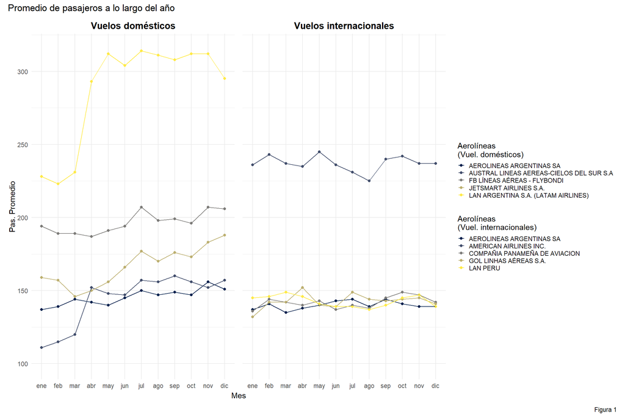

```r
##calculo de promedios para vuelos domesticos e internacionales, redondeados para arriba
mean_domest_mes <- arrange(data_domesticos |> group_by(aerolinea,mes)|>summarize(pas_promedio = ceiling(mean(pasajeros))),mes)
mean_inter_mes <- arrange(data_inter |> group_by(aerolinea,mes)|>summarize(pas_promedio = ceiling(mean(pasajeros))),mes)

##graficos de linea para ambos promedios - se usa la aes group para lograr que la geom_line no resulte en forma de cerrucho
p_line_domest<-mean_domest_mes|>ggplot(aes(mes,pas_promedio,color=aerolinea,group=aerolinea))+
  geom_point()+geom_line()+
  ylim(100,315)+ ##limite manual al eje y para que ambos graficos coincidan
  labs(title="Vuelos domésticos",x="Mes", y="Pas. Promedio",color=md("Aerolíneas\n(Vuel. domésticos)"))+
  scale_color_viridis(option="cividis",discrete=TRUE)+
  theme_lucas

p_line_inter<-mean_inter_mes|>ggplot(aes(mes,pas_promedio,color=aerolinea,group=aerolinea))+
  geom_point()+geom_line()+
  ylim(100,315)+ ##limite manual al eje y para que ambos graficos coincidan
  labs(title="Vuelos internacionales",x="Mes", y="Pas. Promedio",color=md("Aerolíneas\n(Vuel. internacionales)"))+
  scale_color_viridis(option="cividis",discrete=TRUE)+
  theme_lucas

(p_line_domest | p_line_inter) +
  plot_annotation(title='Promedio de pasajeros a lo largo del año',caption="Figura 1")+
    plot_layout(guides="collect",axis_titles = "collect",axes ="collect")
```

### 1.1.4 Discusión

Del Cuadro 1 podemos apreciar que el promedio de pasajeros por aerolínea es de magnitudes similares para ambos tipos de vuelos. Sin embargo, se puede ver que LAN es la aerolínea con el promedio más alto para vuelos domésticos y American Airlines es su contraparte en el caso de vuelos internacionales. Aerolíneas Argentinas está presente en ambos listados, mostrando que, si bien su promedio de pasajeros no es el más elevado, es una elección prevalente para los viajeros.  
En la Figura 1 tenemos una vista más en detalle de los valores del Cuadro 1, pero se respetan los órdenes establecidos por los promedios generales: en los vuelos domésticos se puede observar la predominancia de LAN por sobre las otras aerolíneas, mientras que en los vuelos internacionales, American Airlines es prevalente, al mismo tiempo que el resto de las aerolíneas comparten una franja estrecha. Comparativamente, sus promedios también se encuentran dentro de un rango estrecho (Cuadro 1). En cuanto a la estacionalidad, es decir, cómo se comportan los promedios a lo largo del año, en la Figura 1 se observa que todas las aerolíneas presentan máximos relativos en julio, lo que coincide con las vacaciones de invierno en Argentina. Extrañamente, y contrario a lo esperado, los meses de verano no presentan una estacionalidad marcada. JetSmart y FlyBondi tienen un período de alza en nov-dic, patrón que no se observa en el resto de las empresas. El período ene-mar muestra mínimos para todas las operadoras en comparación al resto del año.  
Los vuelos internacionales no presentan una estacionalidad marcada, salvo por un mínimo absoluto en agosto para American Airlines, con mínimos relativos en el mismo mes para el resto de las operadoras. Es importante destacar que este gráfico toma en cuenta tanto despegues como aterrizajes, por lo que la falta de distinción entre el tipo de operación puede homogeneizar los valores y así esconder estacionalidades del análisis.

## 1.2 Parte 2

**Pregunta:** Para la aerolínea más utilizada en vuelos domésticos, ¿cuál es el destino más visitado históricamente? Adicionalmente, ¿se puede observar una estacionalidad en los destinos conectados por dicha aerolínea?

### 1.2.1 Introducción

Para el análisis de esta segunda parte se utilizarán los datos parcialmente procesados de la Parte 1, rescatando únicamente los vuelos domésticos de LAN ARGENTINA S.A. (LATAM AIRLINES) ya que es la aerolínea más utilizada para este tipo de viajes.

### 1.2.2 Enfoque

Se analizarán el total de vuelos a cada destino, tipificados por provincia. En una primera instancia, se realizará un análisis global para evaluar qué provincia resultó ser la más concurrida y, posteriormente, se evaluarán esos datos de manera estacionaria (meses del año), con el objetivo de entender si hay una estacionalidad en la visita a las provincias.  
Nota: De la Figura 2 ya se puede observar que AER (Buenos Aires) genera un outlier que no permite evaluar adecuadamente la información, por lo que será removido del análisis.

### 1.2.3 Analisis

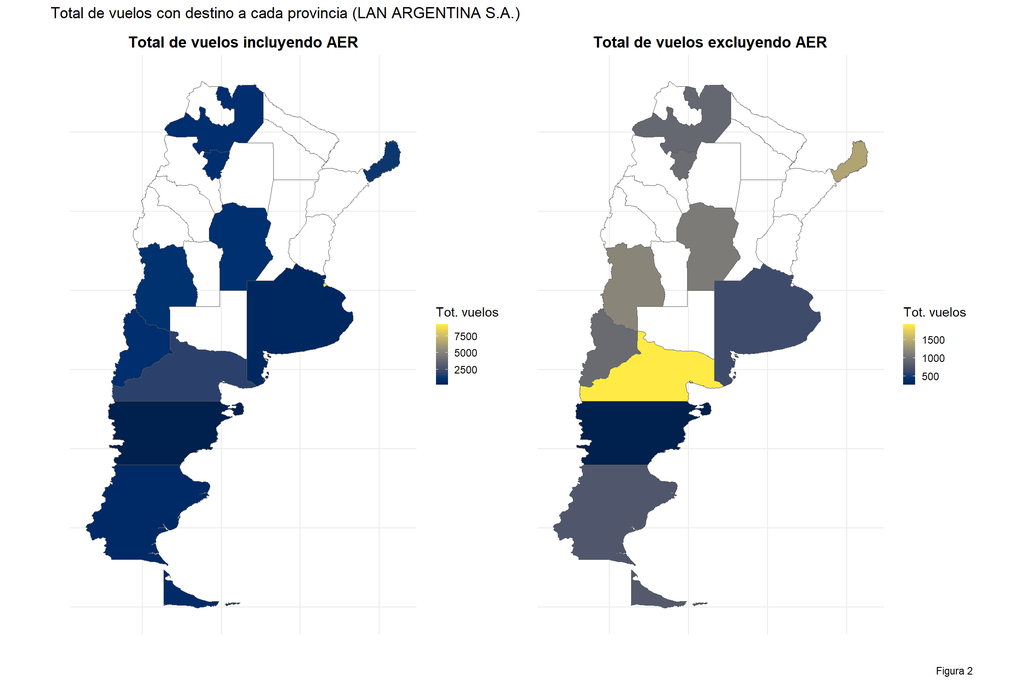

```r
## datos de aeropuertos y sus provincias
ubicacion_aeropuertos <- readr::read_delim("https://datos.transporte.gob.ar/dataset/62b3fe5f-ffe6-4d8f-9d59-bfabe75d1ee8/resource/eb54e49e-9a5a-4614-91f4-526c650d0105/download/aeropuertos_detalle.csv", delim = ";") |>
  rename(latitud = longitud, longitud = latitud) |>
  mutate(provincia = stringr::str_to_title(provincia)) |>
  mutate(provincia = if_else(provincia == "Ciudad Autónoma De Buenos Aires", "Ciudad de Buenos Aires", provincia)) |>
  mutate(provincia = if_else(provincia == "Tierra Del Fuego Antártida E Islas Del Atlántico Sur", "Tierra del Fuego", provincia)) |>
  mutate(provincia = if_else(provincia == "Santiago Del Estero", "Santiago del Estero", provincia)) |>
  mutate(provincia = if_else(provincia == "Santa Fé", "Santa Fe", provincia))
aep_provincias <- select(ubicacion_aeropuertos,local,provincia)

##filtro por LAN y armado de df con nombres de provincias
domest_LAN <- data_domesticos |> filter(aerolinea=="LAN ARGENTINA S.A. (LATAM AIRLINES)")
domest_LAN <-left_join(domest_LAN,aep_provincias,by=c("destino"="local"))

##armado de tabla de frecuencia para vuelos por provincia, removiendo el numero para AER en la segunda
prov_dest_LAN <- arrange(domest_LAN |> group_by(provincia)|>summarize(tot_vuelos = n()),desc(tot_vuelos))
prov_dest_LAN_nobue <- prov_dest_LAN|>mutate(tot_vuelos=if_else(provincia=="Ciudad de Buenos Aires",NA,tot_vuelos))

##mapa de arg con provincias
mapa_prov <- ne_states("Argentina", returnclass = "sf")

##join de los df para obtener la informacion del mapa con las frecuencias previamente calculadas para elaborar la coropleta
prov_dest_LAN <- full_join(prov_dest_LAN,mapa_prov,by=c("provincia"="name"))
prov_dest_LAN_nobue <- full_join(prov_dest_LAN_nobue,mapa_prov,by=c("provincia"="name"))

##coropleta contemplando todos los datos, incluyendo AER
cp_raw<-ggplot(prov_dest_LAN)+
  geom_sf(aes(geometry=geometry, fill = tot_vuelos))+
  scale_fill_viridis(option="cividis",na.value=NA)+
  labs(title="Total de vuelos incluyendo AER",x="",y="",fill="Tot. vuelos")+
  theme_lucas+
  theme(axis.text.x=element_blank(),
        axis.text.y=element_blank())

##coropleta sin AER
cp_nobue<-ggplot(prov_dest_LAN_nobue)+
  geom_sf(aes(geometry=geometry, fill = tot_vuelos))+
  scale_fill_viridis(option="cividis",na.value=NA)+
  labs(title="Total de vuelos excluyendo AER",x="",y="",fill="Tot. vuelos")+
  theme_lucas+
  theme(axis.text.x=element_blank(),
        axis.text.y=element_blank())

(cp_raw | cp_nobue)+
  plot_annotation(title='Total de vuelos con destino a cada provincia (LAN ARGENTINA S.A.)',caption="Figura 2")+
  plot_layout(axis_titles = "collect",axes ="collect")
```

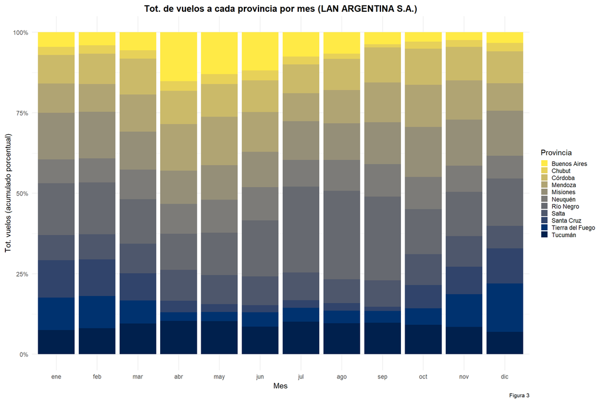

```r
prov_dest_LAN_mes <- arrange(domest_LAN |> group_by(provincia,mes)|>summarize(tot_vuelos = n()),mes)|>filter(provincia!="Ciudad de Buenos Aires")#remover AER para entender mejor el comp. de las provincias

p_area_mes <- ggplot(prov_dest_LAN_mes,aes(x=mes,y=tot_vuelos,fill=provincia))+
  geom_col(position="fill")+
  scale_fill_viridis(option="cividis",discrete = TRUE,direction=-1)+
  theme_lucas+
  scale_y_continuous(labels=scales::percent)+
  labs(title="Tot. de vuelos a cada provincia por mes (LAN ARGENTINA S.A.)",x="Mes",y="Tot. vuelos (acumulado porcentual)",fill="Provincia",caption="Figura 3")

p_area_mes
```

### 1.2.4 Discusión

Podemos observar de la Figura 2 que los viajes a Ciudad de Buenos Aires son mayoritarios, al ser AER el aeropuerto que nuclea las conexiones de todos los vuelos que van del interior del país hacia Buenos Aires. Por ese mismo motivo genera un outlier importante que no permite que la coropleta muestre una gama de colores más amplia para su análisis. Si bien una opción válida podría ser una transformación logarítmica para dar más resolución a la escala, tampoco es de interés mantener AER como destino por lo mencionado anteriormente, y será descartado para este análisis.  
Dicho esto, se puede observar de la coropleta que el destino más popular del país es, por una diferencia notable, la provincia de Río Negro, seguida de Misiones. Es entendible que sean de las provincias más populares como destino ya que cuentan con dos puntos claves y populares para el turismo en el país: Bariloche y las Cataratas de Iguazú. Las provincias que no están coloreadas dentro de la coropleta es, muy probablemente, porque no cuentan con conexión por parte de LAN, ya que no hay aterrizajes de dicha aerolínea en sus respectivos aeropuertos.  
Por otro lado, observando la Figura 3, podemos entender la estacionalidad de cada destino. Río Negro muestra una estacionalidad marcada en invierno y principios de primavera (jul-sep). Misiones, en cambio, tiene un período más largo y estable de afluencia de vuelos en las épocas cálidas del año, entre octubre y febrero.  
Sin embargo, resulta interesante el comportamiento que exhiben otras provincias. Observando la Figura 2, el sur del país no parece ser muy popular, particularmente Chubut, pero el patrón de visita si revela información importante: Tierra del Fuego y Santa Cruz son visitados con mucha más frecuencia durante los meses cálidos del año, con una estacionalidad similar a la de Misiones, entre octubre y marzo. La estacionalidad de estas provincias puede deberse a que durante los meses de invierno, el clima patagónico hace difícil el turismo pero, al derretirse la nieve en primavera y verano, los senderos quedan liberados a ser disfrutados por más visitantes.  
Por último, Buenos Aires (EZE) muestra una afluencia marcada entre abril y agosto, punto que resulta interesante y meritorio de otro análisis más en profundidad para entender esta estacionalidad, ya que en el estudio presente no se evidencia una respuesta clara. Sería interesante incluir EZE y realizar un análisis por separado de la estacionalidad de vuelos de AER y EZE para entender los movimientos de cada uno de estos aeropuertos y su relación a los diferentes eventos que puedan causar patrones en sus operaciones.

### 1.2.5 Extra

Se eligió como paleta para el parcial “Cividis” y, dentro de una búsqueda para encontrar los colores utilizados en hexagesimal, me topé con este [paper](https://journals.plos.org/plosone/article?id=10.1371/journal.pone.0199239), en el que mencionan que la paleta fue desarrollada para adaptar la gama de colores original de “Viridis” para ser mas accesible a personas con deficiencias en la percepción de los colores.  
El color #00204c utilizado en el Cuadro 1 forma parte de los hexagesimales dentro de la escala de Cividis ([link](https://github.com/pnnl/cmaputil/blob/master/colormaps/cividisHexValues.txt))